# TLX Stats

August 13, 2019

# 1 Data Parsing

## 1.1 Loading Data

Filtering out invalid participants (9, 10, and 14).

```r
survey = read.csv("Mobile Input Experiment Survey Responses.csv",sep=",")
survey = survey[,-c(1,2)] %>% filter(!pNo %in% c(9, 10, 14))

tlx.comp = read.csv("NASA-TLX Responses - Comp.csv",sep=",") %>% filter(!Participant.No %in% c(9, 10, 14)) %>% na.omit()
tlx.comp$Task.Type = "Composition"

tlx.trans = read.csv("NASA-TLX Responses - Trans.csv",sep=",") %>% filter(!Participant.No %in% c(9, 10, 14)) %>% na.omit()
tlx.trans$Task.Type = "Transcription"

tlx = bind_rows(tlx.comp, tlx.trans)
```

# 2 Demographic Survey

```r
kable(count(survey, Gender))
```

| Gender | n |
| --- | --- |
| Female | 11 |
| Male | 17 |

```r
#Age stats
ageRange = range(survey$Age)
ageRange[2]
```

```
## [1] 58
```

```r
median(survey$Age)
```

```
## [1] 25
```

```r
sd(survey$Age)
```

```
## [1] 7.228233
```

```r
#Phone Stats
kable(count(survey, PhoneOS))
```

| PhoneOS | n |
| --- | --- |
| Android | 17 |
| iOS | 11 |

```r
#TODO: do something with the usage stats

#Dictation Stats
kable(count(survey, UsedDict))
```

| UsedDict | n |
| --- | --- |
| No | 10 |
| Yes | 18 |

```r
#Filter participants into dictation users and non-dictation users
survey.DictUsers = filter(survey, UsedDict == "Yes")
survey.NonUsers = filter(survey, UsedDict == "No")

kable(count(survey.DictUsers, DictFreq))
```

| DictFreq | n |
| --- | --- |
| Daily | 2 |
| Monthly | 5 |
| Only tried it once or twice | 9 |
| Weekly | 2 |

```r
kable(count(survey.DictUsers, OwnAlexa))
```

| OwnAlexa | n |
| --- | --- |
| No | 8 |
| Yes | 10 |

```r
kable(count(survey.DictUsers, AlexaFreq))
```

| AlexaFreq | n |
| --- | --- |
|  | 8 |
| Daily | 6 |
| Monthly | 1 |
| Weekly | 3 |

```r
kable(count(survey.NonUsers, OwnAlexa2))
```

| OwnAlexa2 | n |
| --- | --- |
| No | 9 |
| Yes | 1 |

28 participants, 11 female, 17 male.

10 of the dictation users owned a Google Home, Alexa, or a similar device. Of these 10, 9 reported they used their device on a daily or weekly basis. Only 1 of the participants who did not use dictation owned a smart assistant.

# 3 NASA-TLX Results

## 3.1 Composition

The only difference that looks big here is that participants found speech much less physically demanding. Speech was slightly more mentally demanding and frustrating, and participants felt their performance was slightly better with Keyboard.

```r
#tlx.melt = melt(tlx.comp, id.vars = c("Input.Type", "Participant.No", "Task.Type")) %>% group_by(variable, Input.Type) %>% summarise(mean=mean(value),ci.upper=ci(value)[3], ci.lower=ci(value)[2])
tlx.melt = melt(tlx.comp, id.vars = c("Input.Type", "Participant.No", "Task.Type"))
```

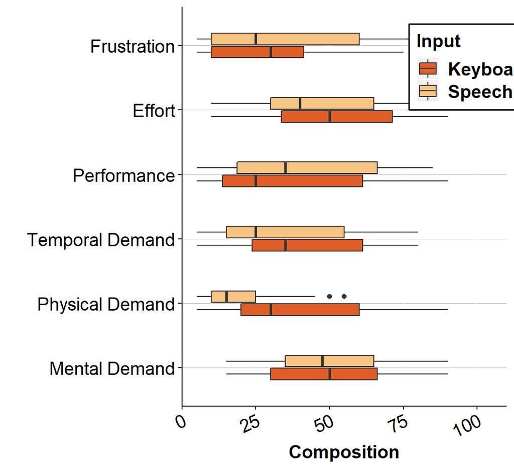

```r
tlx_g <- ggplot(tlx.melt, aes(x=variable, y=value, fill=Input.Type)) + geom_boxplot(width=.4) +
   theme(axis.text.x=element_text(angle=25, hjust=1)) +
   scale_fill_manual(values=c("#DF5E28", "#F6C584")) +
   scale_y_continuous(name="Composition", limits = c(0, 110), minor_breaks = 25, expand = c(0, 0)) +
   scale_x_discrete(name="", labels=c("Mental Demand", "Physical Demand", "Temporal Demand", "Performance", "Effort", "Frustration")) +
   labs(fill = "Input") +
   coord_flip() +
   theme(legend.position = c(.9, .85),
        legend.box.background = element_rect(size=1, color="black"),
        legend.background = element_rect(size = 0.3, linetype = "solid", colour = "black"),
        panel.background = element_blank(),
        panel.border = element_blank(),
        axis.line = element_line(),
        axis.title = element_text(family="Helvetica", face="bold", colour="black", size="14"),
        axis.text = element_text(family="Helvetica", colour="black", size="14"),
        panel.grid.major.y = element_line( size = .1, color = "grey"),
        legend.title = element_text(family="Helvetica", face="bold", colour="black", size="14"),
        legend.text = element_text(family="Helvetica", face="bold", colour="black", size="14"))
tlx_g
```